# Bootstrapping Diabetes Data to Illuminate Factors

## Standard Normal Bootstrap CI

- We used a Standard Normal Bootstrap for each classification, (No Diabetes, Pre-Diabetes, and Diabetes), and pulled out our factors of interest, (Income, BMI, GenHlth, HighBP, and AnyHealthcare).
- We also used different values of sample size, `n`, and number of samples, `m`, to showcase the power of bootstrapping with Normal distributions

### Assumptions:

- Need \(\hat{\theta}\sim N(E[\hat{\theta}],\,\hat{\text{se}}(\hat{\theta})^2)\)
- Need \(\hat{\theta}\) to be unbiased
- Large sample size

## Pairs of `m` and `n` values

Tables of standard error of our estimators

Income and No Diabetes

|  | n=10 | n=25 | n=75 | n=125 | n=250 |
| --- | --- | --- | --- | --- | --- |
| m=10 | 0.659 | 0.497 | 0.319 | 0.268 | 0.177 |
| m=30 | 0.695 | 0.420 | 0.279 | 0.158 | 0.126 |
| m=50 | 0.771 | 0.526 | 0.274 | 0.217 | 0.135 |
| m=100 | 0.694 | 0.475 | 0.258 | 0.219 | 0.149 |
| m=250 | 0.722 | 0.467 | 0.263 | 0.236 | 0.159 |

Income and Pre-Diabetes

|  | n=10 | n=25 | n=75 | n=125 | n=250 |
| --- | --- | --- | --- | --- | --- |
| m=10 | 0.597 | 0.438 | 0.237 | 0.199 | 0.147 |
| m=30 | 0.690 | 0.303 | 0.235 | 0.195 | 0.131 |
| m=50 | 0.675 | 0.362 | 0.251 | 0.177 | 0.115 |
| m=100 | 0.630 | 0.332 | 0.218 | 0.176 | 0.115 |
| m=250 | 0.597 | 0.391 | 0.241 | 0.165 | 0.129 |

Income and Diabetes

|  | n=10 | n=25 | n=75 | n=125 | n=250 |
| --- | --- | --- | --- | --- | --- |
| m=10 | 0.666 | 0.338 | 0.270 | 0.228 | 0.137 |
| m=30 | 0.843 | 0.378 | 0.254 | 0.210 | 0.155 |
| m=50 | 0.750 | 0.454 | 0.282 | 0.168 | 0.140 |
| m=100 | 0.630 | 0.472 | 0.269 | 0.167 | 0.141 |
| m=250 | 0.685 | 0.413 | 0.267 | 0.188 | 0.147 |

HighBP and No Diabetes

|  | n=10 | n=25 | n=75 | n=125 | n=250 |
| --- | --- | --- | --- | --- | --- |
| m=10 | 0.190 | 0.142 | 0.070 | 0.030 | 0.015 |
| m=30 | 0.195 | 0.119 | 0.055 | 0.046 | 0.029 |
| m=50 | 0.150 | 0.108 | 0.066 | 0.039 | 0.037 |
| m=100 | 0.158 | 0.095 | 0.060 | 0.040 | 0.035 |
| m=250 | 0.163 | 0.104 | 0.055 | 0.046 | 0.030 |

HighBP and Pre-Diabetes

|  | n=10 | n=25 | n=75 | n=125 | n=250 |
| --- | --- | --- | --- | --- | --- |
| m=10 | 0.116 | 0.098 | 0.064 | 0.041 | 0.030 |
| m=30 | 0.159 | 0.089 | 0.054 | 0.047 | 0.030 |
| m=50 | 0.160 | 0.108 | 0.048 | 0.041 | 0.030 |
| m=100 | 0.138 | 0.097 | 0.051 | 0.038 | 0.029 |
| m=250 | 0.148 | 0.090 | 0.057 | 0.044 | 0.029 |

HighBP and Diabetes

|  | n=10 | n=25 | n=75 | n=125 | n=250 |
| --- | --- | --- | --- | --- | --- |
| m=10 | 0.117 | 0.071 | 0.030 | 0.034 | 0.021 |
| m=30 | 0.121 | 0.075 | 0.039 | 0.027 | 0.020 |
| m=50 | 0.125 | 0.064 | 0.044 | 0.033 | 0.022 |
| m=100 | 0.106 | 0.067 | 0.039 | 0.029 | 0.023 |
| m=250 | 0.111 | 0.067 | 0.039 | 0.031 | 0.023 |

AnyHealthcare and No Diabetes

|  | n=10 | n=25 | n=75 | n=125 | n=250 |
| --- | --- | --- | --- | --- | --- |
| m=10 | 0.048 | 0.035 | 0.030 | 0.018 | 0.013 |
| m=30 | 0.050 | 0.046 | 0.022 | 0.017 | 0.013 |
| m=50 | 0.081 | 0.042 | 0.024 | 0.017 | 0.014 |
| m=100 | 0.074 | 0.040 | 0.021 | 0.020 | 0.013 |
| m=250 | 0.065 | 0.041 | 0.025 | 0.018 | 0.013 |

AnyHealthcare and Pre-Diabetes

|  | n=10 | n=25 | n=75 | n=125 | n=250 |
| --- | --- | --- | --- | --- | --- |
| m=10 | 0.107 | 0.042 | 0.026 | 0.023 | 0.017 |
| m=30 | 0.050 | 0.035 | 0.025 | 0.023 | 0.015 |
| m=50 | 0.068 | 0.041 | 0.022 | 0.018 | 0.014 |
| m=100 | 0.075 | 0.042 | 0.023 | 0.019 | 0.013 |
| m=250 | 0.065 | 0.043 | 0.023 | 0.020 | 0.014 |

AnyHealthcare and Diabetes

|  | n=10 | n=25 | n=75 | n=125 | n=250 |
| --- | --- | --- | --- | --- | --- |
| m=10 | 0 | 0 | 0 | 0 | 0 |
| m=30 | 0 | 0 | 0 | 0 | 0 |
| m=50 | 0 | 0 | 0 | 0 | 0 |
| m=100 | 0 | 0 | 0 | 0 | 0 |
| m=250 | 0 | 0 | 0 | 0 | 0 |

## Bootstrap t CI

- We used Student-t Bootstraping for each classification, (No Diabetes, Pre-Diabetes, and Diabetes), and pulled out our factors of interest, (Income, BMI, GenHlth, HighBP, and AnyHealthcare).
- We also used different values of sample size, `n`, and number of samples, `m`, to showcase the difference of double bootstrapping with Student-t distributions
- We wanted to show that larger and more samples decreased our standard error of our estimator

### Assumptions:

- Small bias and skewness of \(\hat{\theta}\)
- Need \(\hat{\theta}\) independent of \(\hat{\text{se}}(\hat{\theta})\)

## Pairs of `m` and `n` values

Tables of standard error of our estimators

Income and No Diabetes

|  | n=10 | n=25 | n=75 | n=125 | n=250 |
| --- | --- | --- | --- | --- | --- |
| m=10 | 0.702 | 0.434 | 0.226 | 0.245 | 0.176 |
| m=30 | 0.812 | 0.430 | 0.263 | 0.170 | 0.148 |
| m=50 | 0.732 | 0.476 | 0.240 | 0.183 | 0.130 |
| m=100 | 0.769 | 0.528 | 0.265 | 0.199 | 0.165 |
| m=250 | 0.752 | 0.510 | 0.265 | 0.227 | 0.161 |

Income and Pre-Diabetes

|  | n=10 | n=25 | n=75 | n=125 | n=250 |
| --- | --- | --- | --- | --- | --- |
| m=10 | 0.498 | 0.418 | 0.181 | 0.134 | 0.127 |
| m=30 | 0.620 | 0.402 | 0.229 | 0.179 | 0.109 |
| m=50 | 0.735 | 0.361 | 0.236 | 0.165 | 0.122 |
| m=100 | 0.560 | 0.404 | 0.210 | 0.162 | 0.110 |
| m=250 | 0.652 | 0.365 | 0.224 | 0.172 | 0.131 |

Income and Diabetes

|  | n=10 | n=25 | n=75 | n=125 | n=250 |
| --- | --- | --- | --- | --- | --- |
| m=10 | 0.399 | 0.481 | 0.233 | 0.216 | 0.111 |
| m=30 | 0.658 | 0.396 | 0.234 | 0.157 | 0.139 |
| m=50 | 0.718 | 0.335 | 0.261 | 0.187 | 0.131 |
| m=100 | 0.685 | 0.433 | 0.277 | 0.198 | 0.135 |
| m=250 | 0.704 | 0.412 | 0.253 | 0.194 | 0.143 |

HighBP and No Diabetes

|  | n=10 | n=25 | n=75 | n=125 | n=250 |
| --- | --- | --- | --- | --- | --- |
| m=10 | 0.185 | 0.078 | 0.067 | 0.038 | 0.028 |
| m=30 | 0.152 | 0.107 | 0.054 | 0.055 | 0.031 |
| m=50 | 0.160 | 0.103 | 0.056 | 0.040 | 0.034 |
| m=100 | 0.149 | 0.092 | 0.051 | 0.042 | 0.032 |
| m=250 | 0.162 | 0.102 | 0.057 | 0.046 | 0.031 |

HighBP and Pre-Diabetes

|  | n=10 | n=25 | n=75 | n=125 | n=250 |
| --- | --- | --- | --- | --- | --- |
| m=10 | 0.133 | 0.078 | 0.029 | 0.029 | 0.042 |
| m=30 | 0.126 | 0.101 | 0.052 | 0.047 | 0.029 |
| m=50 | 0.139 | 0.094 | 0.051 | 0.049 | 0.030 |
| m=100 | 0.158 | 0.106 | 0.054 | 0.042 | 0.027 |
| m=250 | 0.154 | 0.097 | 0.057 | 0.046 | 0.029 |

HighBP and Diabetes

|  | n=10 | n=25 | n=75 | n=125 | n=250 |
| --- | --- | --- | --- | --- | --- |
| m=10 | 0.118 | 0.072 | 0.038 | 0.029 | 0.017 |
| m=30 | 0.097 | 0.078 | 0.037 | 0.024 | 0.021 |
| m=50 | 0.116 | 0.066 | 0.040 | 0.033 | 0.020 |
| m=100 | 0.112 | 0.069 | 0.041 | 0.034 | 0.020 |
| m=250 | 0.112 | 0.069 | 0.042 | 0.033 | 0.022 |

AnyHealthcare and No Diabetes

|  | n=10 | n=25 | n=75 | n=125 | n=250 |
| --- | --- | --- | --- | --- | --- |
| m=10 | 0.048 | 0.061 | 0.034 | 0.015 | 0.017 |
| m=30 | 0.073 | 0.050 | 0.021 | 0.021 | 0.013 |
| m=50 | 0.068 | 0.037 | 0.023 | 0.017 | 0.013 |
| m=100 | 0.053 | 0.045 | 0.023 | 0.019 | 0.013 |
| m=250 | 0.075 | 0.040 | 0.024 | 0.019 | 0.012 |

AnyHealthcare and Pre-Diabetes

|  | n=10 | n=25 | n=75 | n=125 | n=250 |
| --- | --- | --- | --- | --- | --- |
| m=10 | 0.097 | 0.051 | 0.019 | 0.023 | 0.014 |
| m=30 | 0.068 | 0.043 | 0.022 | 0.015 | 0.011 |
| m=50 | 0.068 | 0.044 | 0.030 | 0.020 | 0.015 |
| m=100 | 0.065 | 0.046 | 0.025 | 0.018 | 0.013 |
| m=250 | 0.063 | 0.043 | 0.023 | 0.019 | 0.015 |

AnyHealthcare and Diabetes

|  | n=10 | n=25 | n=75 | n=125 | n=250 |
| --- | --- | --- | --- | --- | --- |
| m=10 | 0 | 0 | 0 | 0 | 0 |
| m=30 | 0 | 0 | 0 | 0 | 0 |
| m=50 | 0 | 0 | 0 | 0 | 0 |
| m=100 | 0 | 0 | 0 | 0 | 0 |
| m=250 | 0 | 0 | 0 | 0 | 0 |

## Income

Normal CI on Income

|  | mean | lower | upper |
| --- | --- | --- | --- |
| No Diabetes | 5.185 | 5.073 | 5.296 |
| Pre-Diabetes | 4.949 | 4.858 | 5.039 |
| Diabetes | 4.874 | 4.771 | 4.977 |

Student-t CI on Income

|  | mean | lower | upper |
| --- | --- | --- | --- |
| No Diabetes | 5.170 | 3.695 | 5.890 |
| Pre-Diabetes | 4.951 | 4.253 | 5.107 |
| Diabetes | 4.862 | 4.200 | 4.944 |

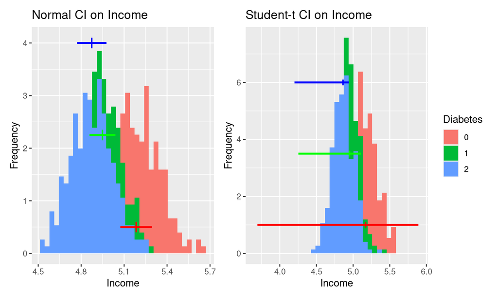

## BMI

Normal CI on BMI

|  | mean | lower | upper |
| --- | --- | --- | --- |
| No Diabetes | 28.380 | 28.165 | 28.594 |
| Pre-Diabetes | 32.889 | 32.639 | 33.140 |
| Diabetes | 29.257 | 29.022 | 29.492 |

Student-t CI on BMI

|  | mean | lower | upper |
| --- | --- | --- | --- |
| No Diabetes | 28.406 | 28.324 | 29.694 |
| Pre-Diabetes | 32.903 | 31.281 | 35.848 |
| Diabetes | 29.239 | 25.658 | 31.068 |

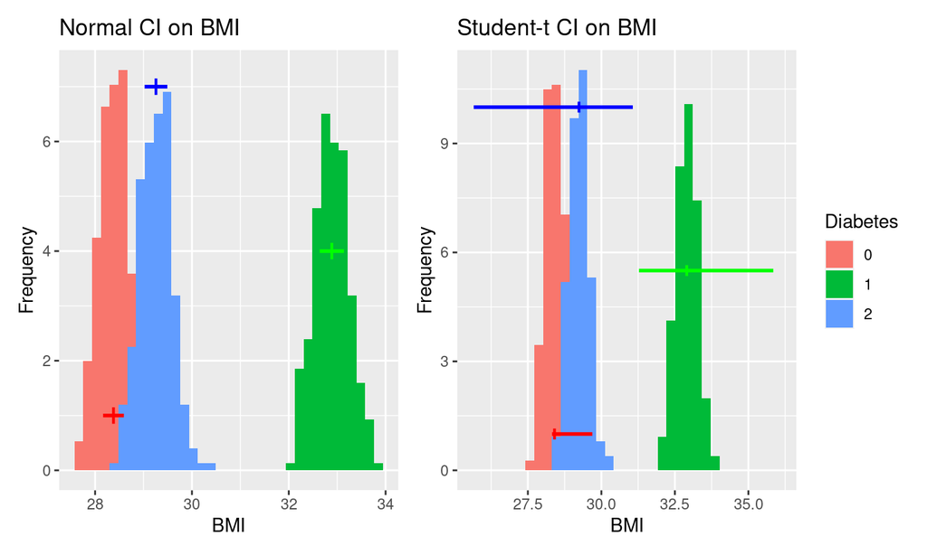

## GenHlth

Normal CI on GenHlth

|  | mean | lower | upper |
| --- | --- | --- | --- |
| No Diabetes | 2.863 | 2.812 | 2.913 |
| Pre-Diabetes | 3.586 | 3.534 | 3.638 |
| Diabetes | 3.044 | 2.987 | 3.100 |

Student-t CI on GenHlth

|  | mean | lower | upper |
| --- | --- | --- | --- |
| No Diabetes | 2.866 | 2.471 | 3.506 |
| Pre-Diabetes | 3.595 | 3.106 | 4.398 |
| Diabetes | 3.036 | 2.622 | 3.142 |

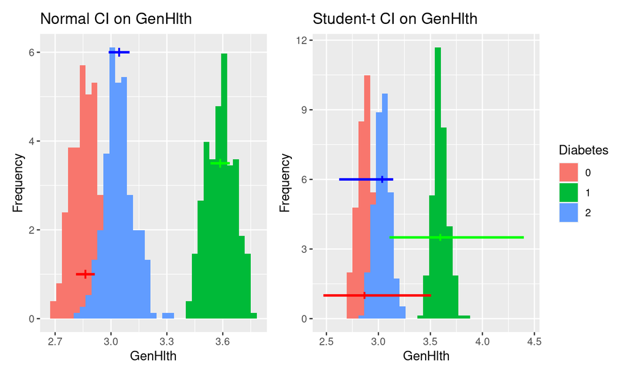

## HighBP

Normal CI on HighBP

|  | mean | lower | upper |
| --- | --- | --- | --- |
| No Diabetes | 0.591 | 0.570 | 0.612 |
| Pre-Diabetes | 0.634 | 0.614 | 0.655 |
| Diabetes | 0.864 | 0.847 | 0.880 |

Student-t CI on HighBP

|  | mean | lower | upper |
| --- | --- | --- | --- |
| No Diabetes | 0.590 | 0.433 | 0.879 |
| Pre-Diabetes | 0.637 | 0.592 | 0.697 |
| Diabetes | 0.865 | 0.799 | 1.054 |

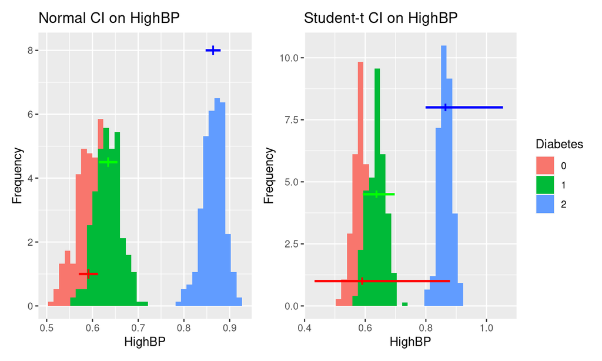

## AnyHealthcare

Normal CI on AnyHealthcare

|  | mean | lower | upper |
| --- | --- | --- | --- |
| No Diabetes | 0.955 | 0.946 | 0.964 |
| Pre-Diabetes | 0.953 | 0.944 | 0.963 |
| Diabetes | 1.000 | 1.000 | 1.000 |

Student-t CI on AnyHealthcare

|  | mean | lower | upper |
| --- | --- | --- | --- |
| No Diabetes | 0.953 | 0.939 | 0.984 |
| Pre-Diabetes | 0.954 | 0.936 | 1.015 |
| Diabetes | 1.000 | NaN | NaN |

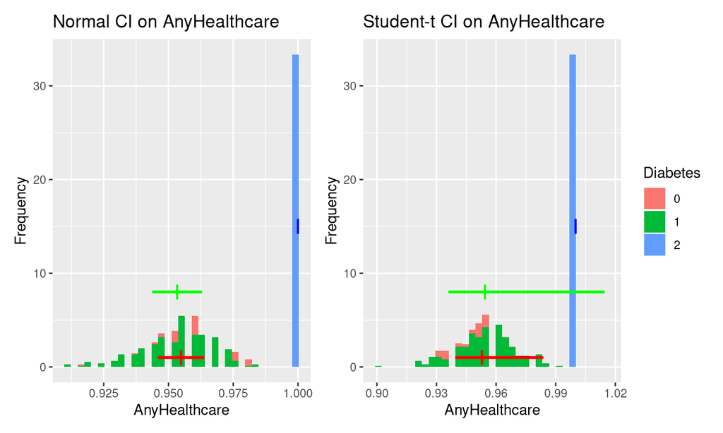